# Quantitative research

Mike Hammond and Adriana Picoral

Oct 28, 2021

## Agenda

- What is quantitative research?
- An extended example

# Overview

## What is quantitative research?

- Empirical research tested by some quantitative comparison
- For example:
  - “nouns are bigger than verbs”
  - “length of clauses in academic writing increases with grade level”
  - “probability of *estar* use (compared to *ser*) in L2 Spanish increases with proficiency”
  - “measures of accuracy, fluency, and complexity increase with L2 proficiency”

## How do we do quantitative research?

- Collect quantitative data.
- Asses the quantitative comparison statistically.
- For *some* folks, just looking at the numbers might suffice, but typically not.

## How do we collect quantitative data for language?

- corpus data
- experimental data
- assessment data
- all of these require design and analysis choices.

## How do we assess quantitative comparisons statistically?

- It’s not enough to say that $x$ is a bigger number than $y$.
- Two numbers may differ by chance, not because your hypothesis is correct.

# Example: nouns and verbs

## Nouns are bigger than verbs

- Let’s look at the hypothesis that “nouns are bigger than verbs”.
- This is vague in several dimensions.
- In what sense are they bigger? Letters? Phonemes? Syllables?
- In what context are they bigger? In dictionaries? The words an individual chooses to say? In some text? If in texts, what kind of text?

## Assumptions

1. Let’s assume this means orthographically: *on average*, nouns have more letters.
2. Let’s assume this means the words people *use*.

# Behavioral data

## Behavioral data

- Behavioral experiments are one source of quantitative data.
- We asked people to give us 10 random verbs and nouns.
- We now analyze those data and we use `R` for that. (We hide the `R` code here, but it’s all available at picoral/slat-talk-fall-2021 on github.)

## Preliminary analysis

Here are the mean lengths in terms of characters. We see that there is an apparent difference.

| word_type | mean |
| --- | --- |
| nouns | 5.463790 |
| verbs | 4.916923 |

## Native language

There also seems to be a difference as a function of native language. (Here we only include cases where we have more than one speaker of a language.)

| native_language | nouns | verbs |
| --- | --- | --- |
| arabic | 5.36 | 4.60 |
| english | 5.59 | 5.09 |
| french | 5.65 | 4.20 |
| korean | 5.20 | 4.57 |
| portuguese | 5.45 | 4.80 |
| russian | 4.87 | 4.17 |

Are these differences significant or just accidental?

## Significance testing

Linear mixed effects test shows that the noun vs. verb distinction is significant, but native language does not show a significan effect with these data.

|  | Estimate | Std. Error | df | t value | Pr(>\|t\|) |
| --- | --- | --- | --- | --- | --- |
| (Intercept) | 5.5914538 | 0.1601065 | 88.65484 | 34.9233325 | 0.0000000 |
| word_typeverbs | -0.4987708 | 0.1269531 | 1232.04834 | -3.9287817 | 0.0000901 |
| english_l1non-english | -0.3456204 | 0.2634211 | 88.56746 | -1.3120453 | 0.1928953 |
| word_typeverbs:english_l1non-english | -0.1303958 | 0.2088430 | 1232.02959 | -0.6243724 | 0.5324986 |

# Corpus data

## Corpus data

Let’s see if a similar pattern holds for corpus data. We use a *teeny* snippet of the tagged Brown corpus: “`ca01`” file with just 2242 words.

## Do character counts

Here are the mean character counts for our subset:

| Nouns | Verbs |
| --- | --- |
| 6.8485401 | 6.1547619 |

## Significance testing for corpus counts

- Is this difference significant?
- *t*-test: *t*(607.5681102) = 3.9930405, *p* = 0.000073

# MICUSP

## Another corpus analysis

We can examine the role of L1 for our question with this corpus.

- Michigan Corpus of Upper-Level Student Papers
- https://micusp.elicorpora.info/

## Basic language data in MICUSP

| L1 English? | Total Participants |
| --- | --- |
| yes | 681 |
| no | 148 |

## Means by language

With these data there is an interesting interaction between nouns/verbs and L1.

| word_type | group | mean_word_length | mean_lemma_length |
| --- | --- | --- | --- |
| nouns | L1 English | 6.997737 | 6.732711 |
| nouns | Other L1 | 7.135945 | 6.862248 |
| verbs | L1 English | 6.438132 | 5.537843 |
| verbs | Other L1 | 6.320506 | 5.442388 |

## Let’s look at it

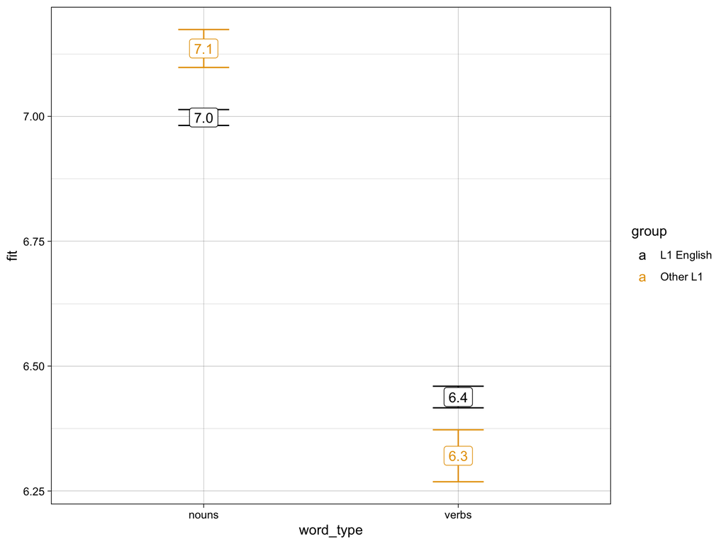

## Is this significant?

|  | Estimate | Std. Error | t value | Pr(>\|t\|) |
| --- | --- | --- | --- | --- |
| (Intercept) | 6.9977369 | 0.0081019 | 863.710424 | 0 |
| word_typeverbs | -0.5596050 | 0.0136876 | -40.884168 | 0 |
| groupOther L1 | 0.1382077 | 0.0210100 | 6.578170 | 0 |
| word_typeverbs:groupOther L1 | -0.2558339 | 0.0355935 | -7.187659 | 0 |

# Summary

## Conclusion

- There’s lots of interesting stuff to do quantitatively.
- There’s a *bit* of an entry cost in terms of how you process texts and statistics. (We can help you with this!!!)
- We like numbers.
- We like `R`.

# Appendix

## Is the lemma length difference significant?

It’s *not* because people cite or use inflected forms.

|  | Estimate | Std. Error | t value | Pr(>\|t\|) |
| --- | --- | --- | --- | --- |
| (Intercept) | 6.7327109 | 0.0077327 | 870.685259 | 0 |
| word_typeverbs | -1.1948679 | 0.0130637 | -91.464825 | 0 |
| groupOther L1 | 0.1295368 | 0.0200524 | 6.459913 | 0 |
| word_typeverbs:groupOther L1 | -0.2249918 | 0.0339711 | -6.623029 | 0 |

## Let’s look at it again

We plot just the lemmas here.

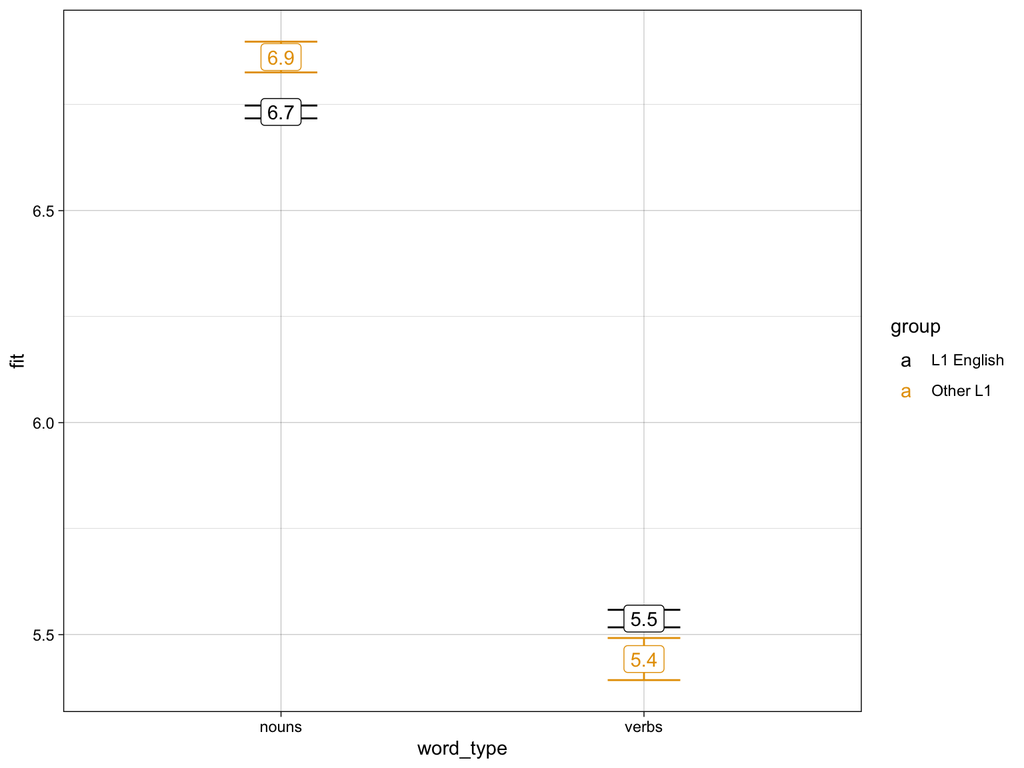

## Most common verbs by group

There is a known effect whereby non-natives use the verb *can* more frequently (Deshors and Gries, 2014).

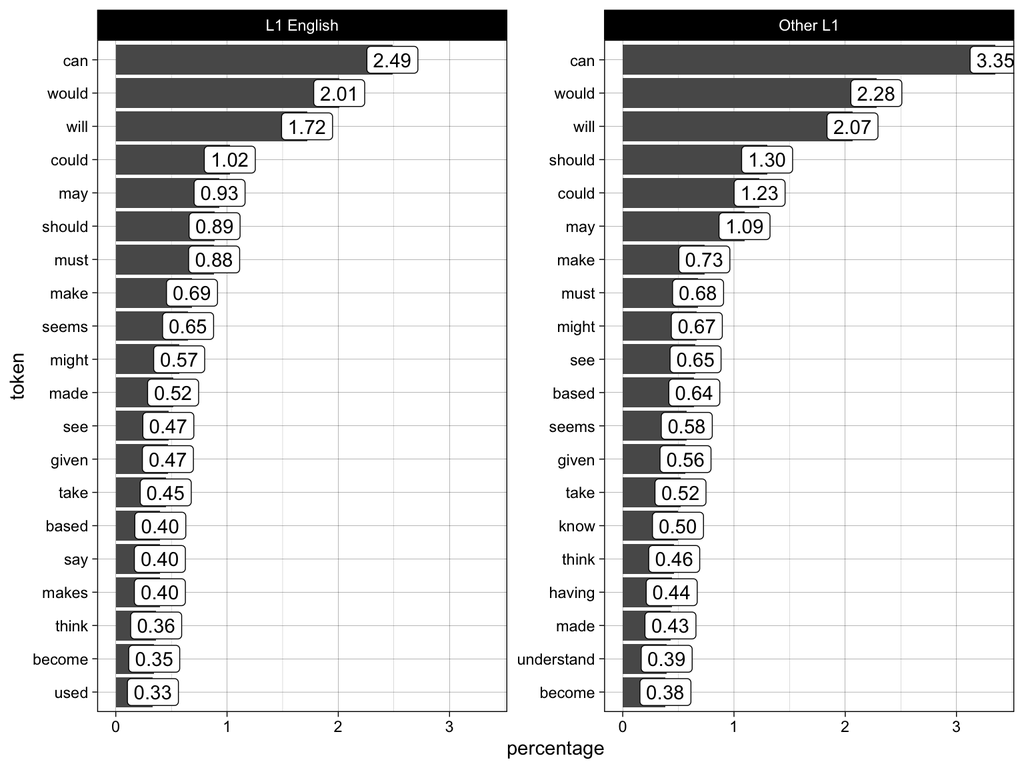

## Most common verb lemmas by group

Here’s the same effect just looking at lemmas.

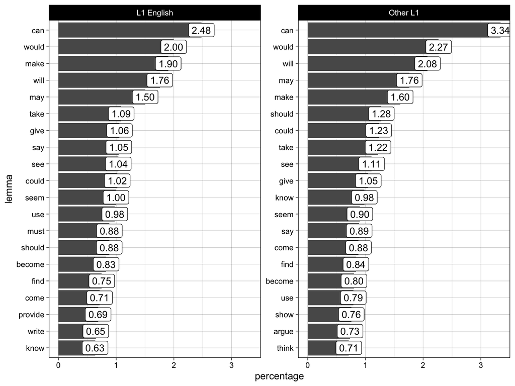